# Priors

2022-10-25

Visualizing choice of priors.

## Seeds

Seed Parameter

Units

Reasoning

Density

Density (Original Scale)

Mean $$\sim N(\mu, \sigma)$$ $$\mu=\log(10)$$ $$\sigma=\frac{\log(40)-\log(5)}{4}$$

log of seed count

Using log of seed count because median of seed count should be left-skewed, higher probability of lower counts? Median of observed seed count is 10. Using median because median of log-normal = log of median of normal  
Setting sd to range from a seed count of 5 to 40 Do I need to compute median of seed count + 1 or just median of seed count ?  
Was using method of moments for log-normal but I am not sure how this translates when using the median and might be overkill.

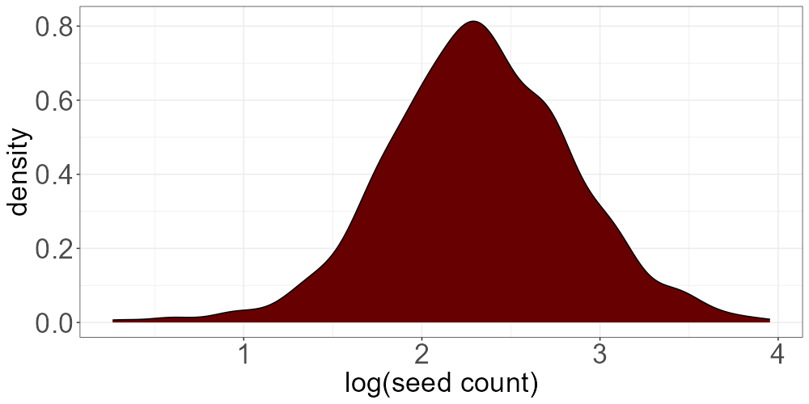

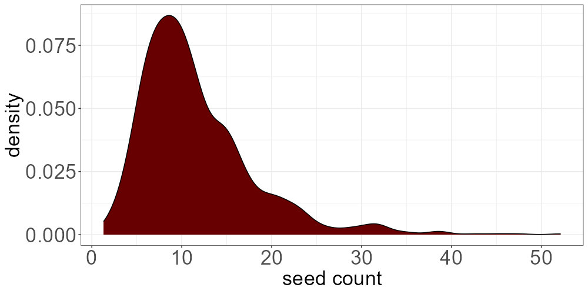

Seed Parameter

Units

Reasoning

Density

Matern Shape $$\sim U(0.5,4)$$

None?

Understanding plausible ecological values would be challenging. These are typical values used in geostatistical models, should describe what happens outside of this range.

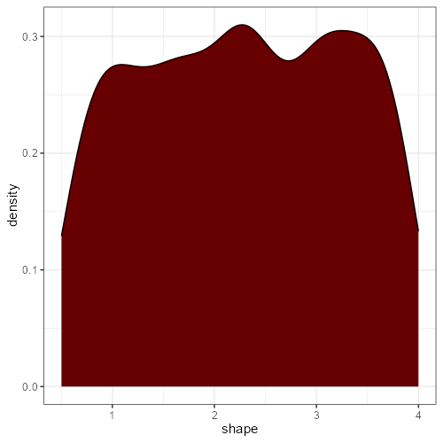

Seed Parameter

Units

Reasoning

Density

Density (Original Scale)

Matern Reparametrized Scale $$\sim exp(GN(\mu,\sigma))$$ $$\mu=(log(3)+log(50))/2$$ $$\alpha \approx 1.39 $$ $$\beta \approx 4.76$$ $$\sigma^2=\frac{\alpha \Gamma(3/\beta)}{\Gamma(1/\beta)} \approx 0.453$$ $$\sigma \approx 0.67$$

m

Using generalized-normal because we can make use of `get_gnorm` function to specify tail and centre probabilties with ranges, specifically we can specify how heavy we want the tails. Mean and sd are on the log scale. Generalized normal is symmetric, but on log-scale it is left-skewed which agrees with ecological knowledge that seed dispersal would occur on scales less than 60m. Lower and upper values in `get_gnorm` were set to approximately small and large distances between locations in the observed seed dataset (not many distances below 3m or above 50m)
We exponentiate to get the units back on the original scale (metres). $$\alpha \beta$$ are outputs from `get_gnorm` function, when beta is larger than 2 get heavier tails than gaussian, alpha relates to sd. Why not use log-normal, more control with GN distribution?

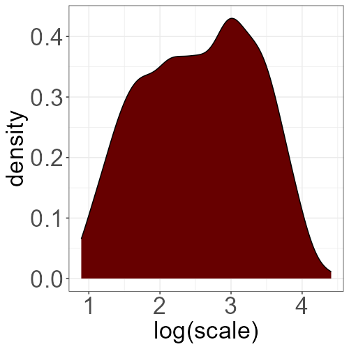

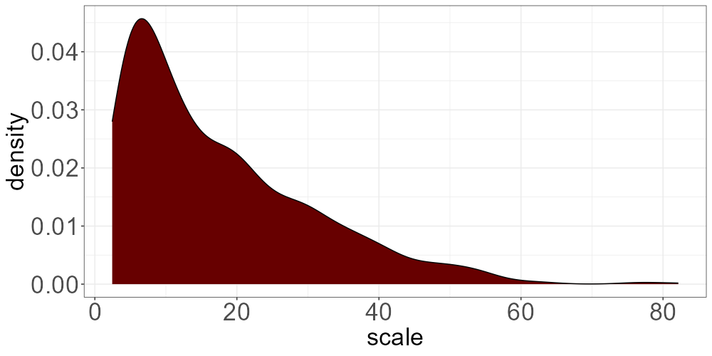

Seed Parameter

Units

Reasoning

Density

Density (Original Scale)

Nugget Proportion $$\sim N(\mu,\sigma)$$ $$\mu=logit(0.1)$$ $$\sigma=\frac{logit(0.4)-logit(0.01)}{4}$$

proportion

Proportion of variance described by small scale noise should be small, less than 50%. Want the mean propotion to range from 0.01 to 0.4, sd of (logit(0.4)-logit(0.01))/4 (2 standard deviations, 95% of data). For now, arbitrarily setting mean proportion to 0.1

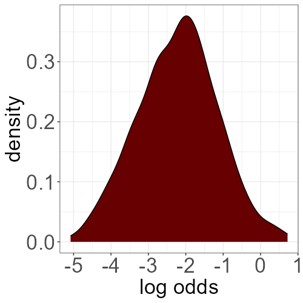

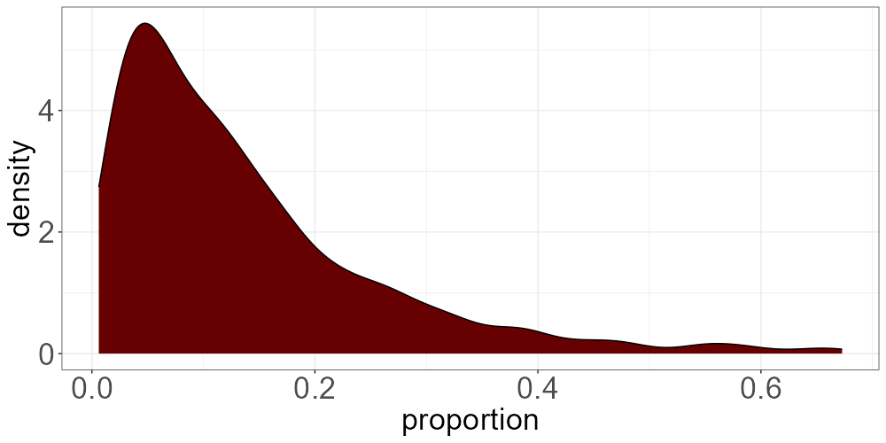

Seed Parameter

Units

Reasoning

Density

Density (Original Scale)

Standard Deviation $$\sim N(\mu,\sigma)$$ $$\mu=\log(0.25)$$ $$\sigma=\frac{\log(0.95) - \log(0.05)}{4}$$

sd of log(seed count)

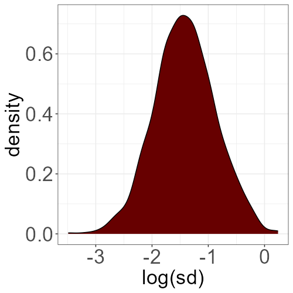

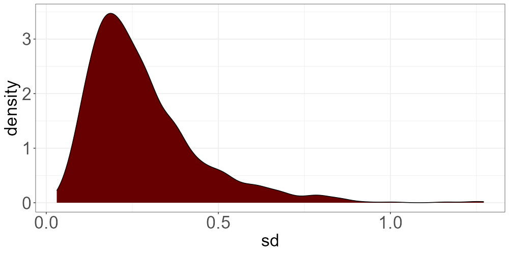

## Establishment

Establishment Parameter

Units

Reasoning

Density

Matern Shape $$\sim U(0.5,4)$$

None?

Same as seed prior.

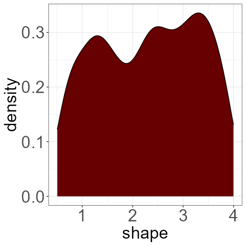

Establishment Parameter

Units

Reasoning

Density

Density (Original Scale)

Matern Reparametrized Scale $$\sim exp(GN(\mu,\sigma))$$ $$\mu=(log(3)+log(50))/2$$ $$\alpha \approx 1.33 $$ $$\beta \approx 12.24$$ $$\sigma^2=\frac{\alpha \Gamma(3/\beta)}{\Gamma(1/\beta)} \approx 0.42$$ $$\sigma \approx 0.65$$

m

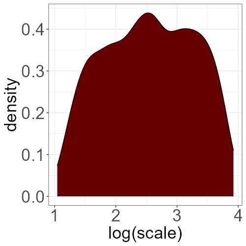

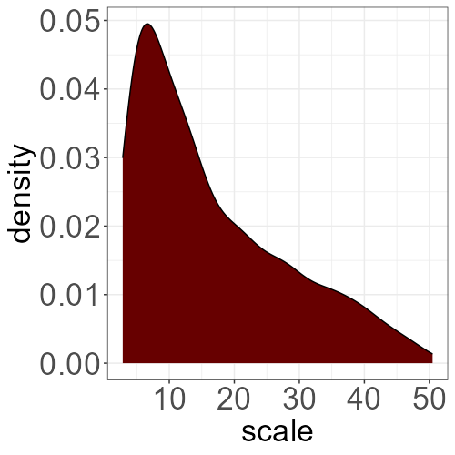

Establishment Parameter

Units

Reasoning

Density

Density (Original Scale)

Nugget Proportion $$\sim N(\mu,\sigma)$$ $$\mu=logit(0.1)$$ $$\sigma=\frac{logit(0.4)-logit(0.01)}{4}$$

proportion

Same as seed prior.

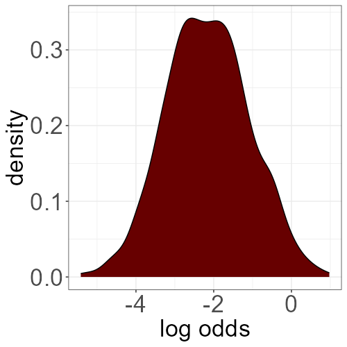

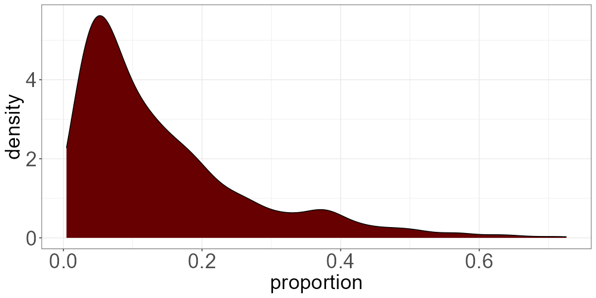

Establishment Parameter

Units

Reasoning

Density

Density (Original Scale)

Mean $$\sim N(\mu, \sigma)$$ $$\mu=logit(0.1)$$ $$\sigma=\frac{logit(0.5)-logit(0.01)}{4}$$

log odds

Probability of seed establishing should be less than 50%, trees drop many more seeds than result in established plants. Very crude measurement, average of observed seedling count divided by average of observed seed count approx 0.064, setting mean to 10% on probability scale logit(0.1). Want the mean to range from 0.01 to 0.5 on the probability scale, sd of (logit(0.5)-logit(0.01))/4 (2 standard deviations, 95% of data). See generation of establishment distribution before, seems reasonable, may need some tweaking.

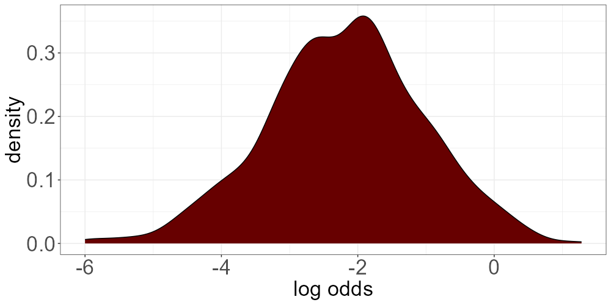

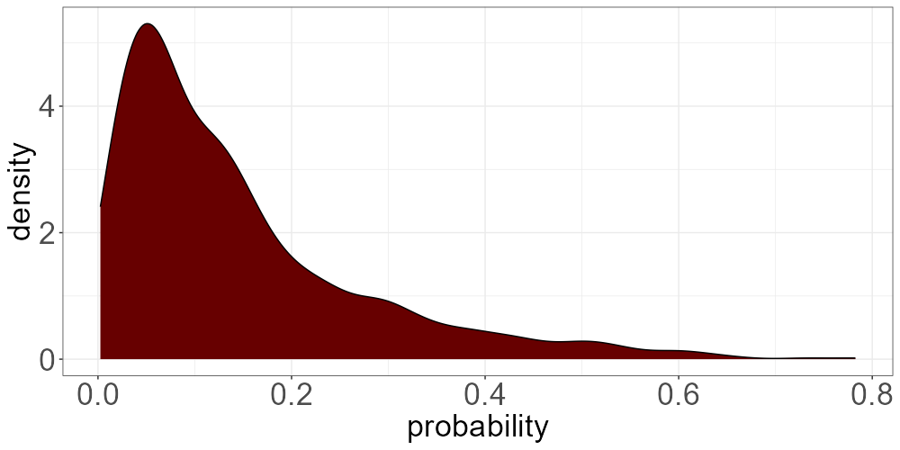

Establishment Parameter

Units

Reasoning

Density

Density (Original Scale)

Standard Deviation $$N(\mu, \sigma)$$ $$\mu=\log(1)$$ $$\sigma=\frac{\log(3.5)-\log(0.5)}{4}$$

log(sd on log-odds)

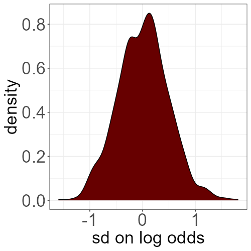

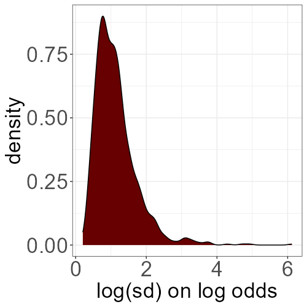

## Prior Predictive Checks

### Mean Establishment Probability

$logit(p_i) \sim N(\mu_i,\sigma_i)$

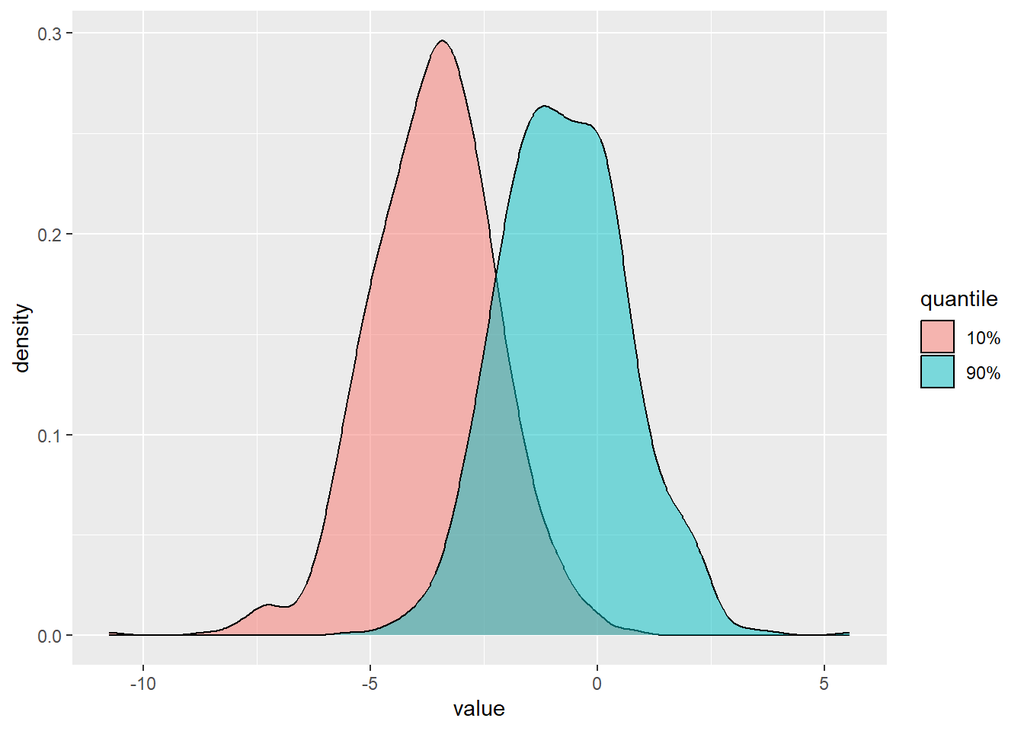

```r
mu_i <- list()
sigma_i <- list()
logitp_i <- list()
q <- list()

seed_base <- 111
for (i in 1:1000){

  set.seed(seed_base+i)

  #sample mu_i
  mu_i[[i]]<-rnorm(n=1, mean=logit(0.1), sd=((logit(0.5))-(logit(0.01)))/4)

  #sample sigma_i
  sigma_i[[i]]<-rnorm(n=1, mean=log(1), sd=(log(3.5)-log(0.5))/4)

  #sample logit(e_i), compute quantiles
  logitp_i[[i]] <- rnorm(1000,mean=mu_i[[i]],sd=exp(sigma_i[[i]]))
  q[[i]] <- quantile(logitp_i[[i]],probs=c(0.1,0.9))
}
sum_q <- (bind_rows(q)
          %>% pivot_longer(cols=everything(),names_to = "quantile",values_to = "value"))

# look at quantiles
(ggplot(sum_q,aes(x=value,fill=quantile))+geom_density(alpha=0.5))
```

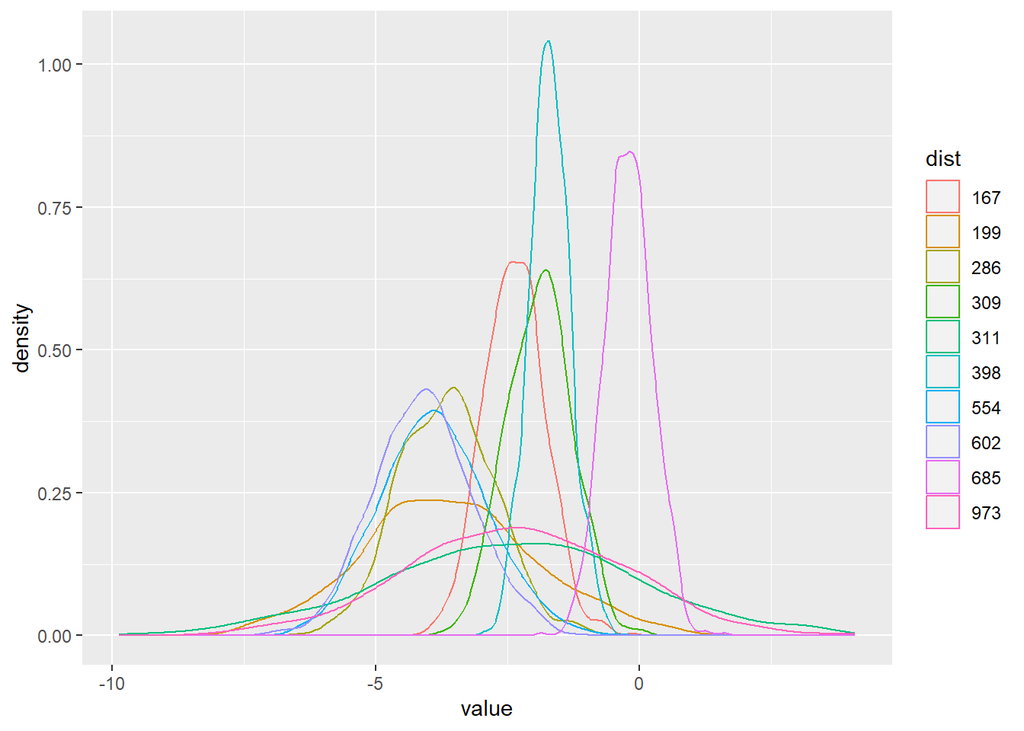

```r
# look at distributions from 10 random samples
names(logitp_i)=seq(1,length(logitp_i),by=1)
all_dist <- (sample(logitp_i,10)
             %>% bind_rows()
             %>% pivot_longer(cols=everything(),names_to = "dist",values_to = "value")
)

(ggplot(all_dist, aes(x=value,col=dist))+geom_density())
```

### Mean Seed Count

$\log(seed count_i) \sim N(\mu_i,\sigma_i)$ These results look fairly reasonable, it’s possible the sd is a little large. The mean is really the median…Not clear whether I am including the sd in the distribution appropriately (exponentiating sd on the log scale to use in a log-normal?)

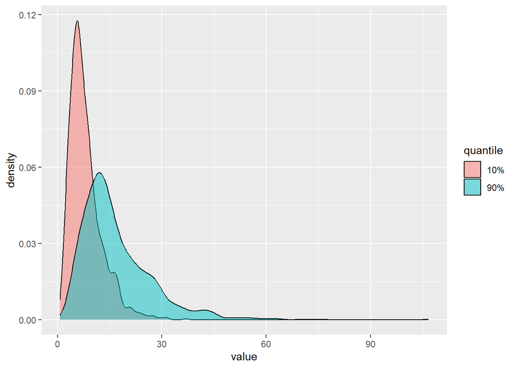

```r
#sdlog - 1 seems large, 1.5 too large, 0.1 seems smallish
# g <- rnorm(100,mean=log(10),sd=(log(40)-log(5))/4)
# t <- rnorm(100,mean=log(0.2),sd=(log(0.95)-log(0.01))/4)
seed_sd <- rnorm(n=1000,mean=log(0.25),sd=(log(0.90)-log(0.1))/4)
# but sd(log of seed count) \approx cv of seed count
seed_mu <- rnorm(n=1000, mean = log(median(seeds$count)), sd = (log(40)-log(5))/4)

# seed_sd_log <- exp(seed_sd^2-1)*exp(2*seed_mu+seed_sd^2)
# seed_mu_log <- exp(seed_mu + (seed_sd^2)/2)
#
# seed_sd <- rnorm(n=1000,mean=5,sd=(10-1)/4)
# # but sd(log of seed count) \approx cv of seed count
# seed_mu <- rnorm(n=1000, mean = 10, sd = (40-5)/4)

#seed_cv <- rnorm(n=1000,mean=log(0.5),sd=(log(1)-log(0.01))/4)
#solve for sd
#seed_sd <- exp(seed_mu)*exp(seed_cv)
#solve for cv
# seed_cv <- exp(seed_sd)/exp(seed_mu)
seed_count <- list()
q <- list()
for (i in 1:1000){
    # seed_count[[i]] <- rnorm(1000,mean=seed_mu[i],sd=seed_sd[i])

  seed_count[[i]] <- exp(rnorm(1000,mean=seed_mu[i],sd=exp(seed_sd[i])))


  #seed_count[[i]] <- rlnorm(1000,meanlog=seed_mu[i],sdlog=exp(seed_sd[i]))

    # seed_count[[i]] <- rlnorm(1000,meanlog=seed_mu_log[i],sdlog=seed_sd_log[i])

  q[[i]] <- quantile(seed_count[[i]],probs=c(0.1,0.9))
}
# hist(unlist(seed_count))
# hist(exp(unlist(seed_count)),breaks=100)
sum_q <- (bind_rows(q)
          %>% pivot_longer(cols=everything(),names_to = "quantile",values_to = "value"))

# look at quantiles
(ggplot(sum_q,aes(x=value,fill=quantile))+geom_density(alpha=0.5))
```

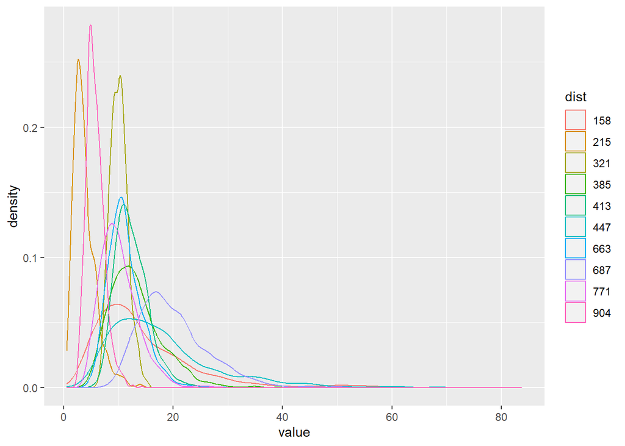

```r
# look at distributions of 10 random samples
names(seed_count)=seq(1,length(seed_count),by=1)
all_dist <- (sample(seed_count,10)
             %>% bind_rows()
             %>% pivot_longer(cols=everything(),names_to = "dist",values_to = "value")
)

(ggplot(all_dist, aes(x=value,col=dist))+geom_density())
```

## Investigating reparametrization of Matérn

$$\alpha=2\phi\sqrt{\kappa}$$

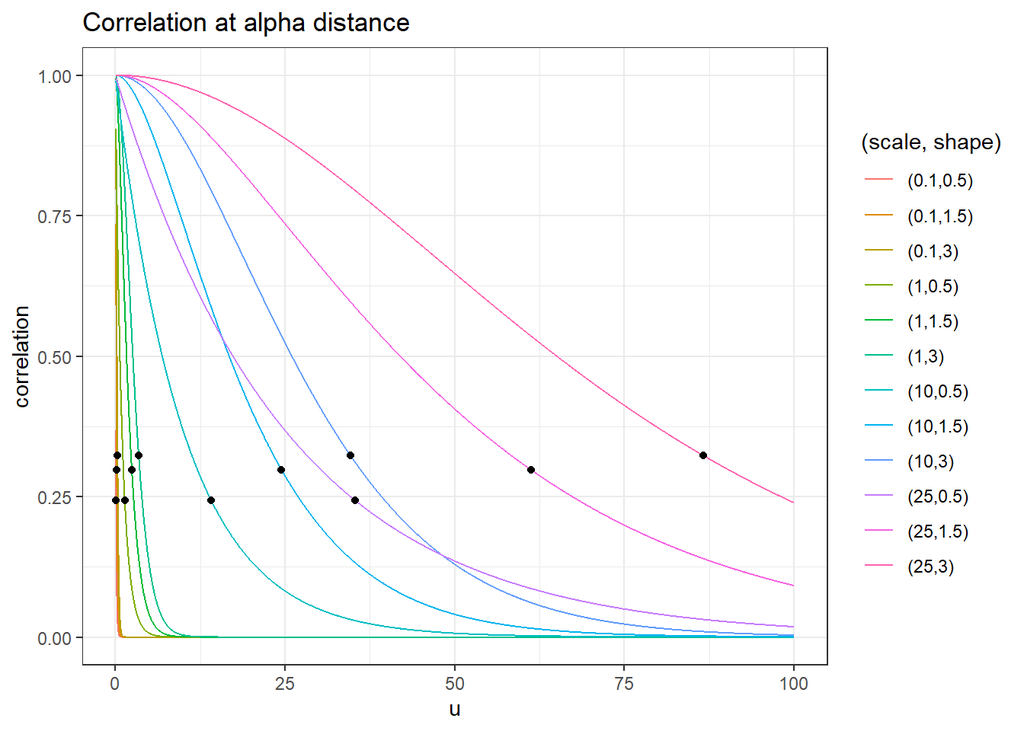

Correlation looks approximately constant around $\approx 0.3$ for all $\alpha$ values.

Simulating seeds at the same spatial locations using Matern with specified values of $\alpha$. Interpreting $\alpha$ as patch size.

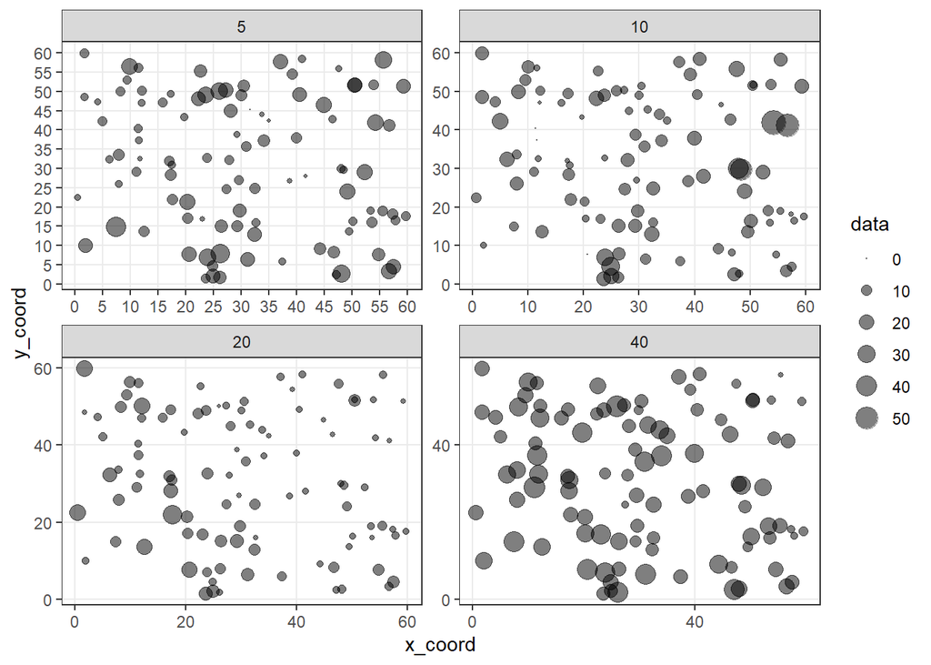

Difficult to see patches in this way, What if I used a regular grid instead.

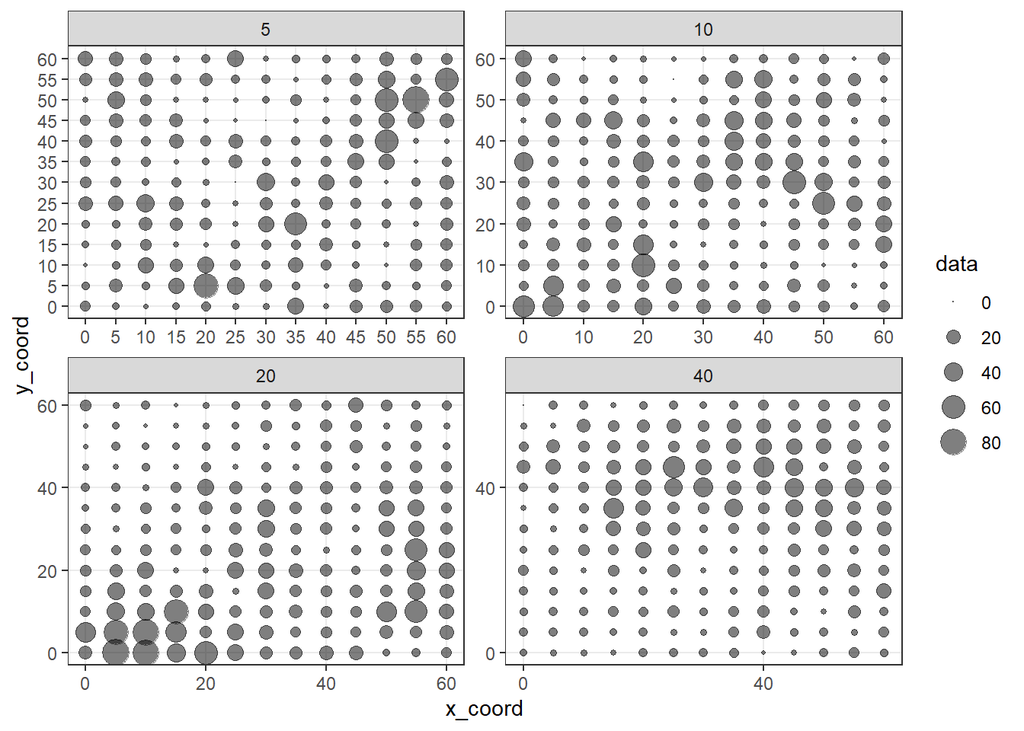

More obvious that $\alpha$ is approximate patch size.